# An Analysis of Weather Events and Their Impacts in the United States: 2024

Brian Punch-Eastman

## 1 Synopsis

This study examines the frequency, geographic distribution, population health impacts, and economic consequences of severe weather events recorded in the National Oceanic and Atmospheric Administration (NOAA) Storm Events Database during 2024. Three datasets containing weather event details, fatalities, and geographic locations were integrated and processed using R. The final analytical dataset contained 69,802 weather event records, representing 50 event types across 68 geographic areas. Thunderstorm wind was the most frequently recorded weather event, while excessive heat caused the greatest number of deaths and tornadoes caused the greatest number of injuries. Texas recorded the highest frequency of weather events, while May was the most active month and summer was the most active season. Hurricanes and typhoons generated the greatest combined economic damage, with Florida experiencing the highest reported economic losses. Total known reported property and crop damage amounted to approximately $18 billion, with 80.17% occurring during the fall season. These findings highlight the importance of geographic and seasonal considerations in disaster preparedness, public health protection, and economic risk management. The analysis also acknowledges limitations associated with incomplete damage information, discrepancies in fatality reporting, and the use of a single year of weather data.

## 2 Data Processing

### 2.1 Data Source

The data used in this research were obtained from the National Oceanic and Atmospheric Administration (NOAA) National Centers for Environmental Information (NCEI) Storm Events Database.

The analysis focuses on weather events recorded during the 2024 calendar year and incorporates three datasets:

- Storm Events Details: Contains event classifications, geographic information, deaths, injuries, property damage, and crop damage.
- Storm Events Fatalities: Contains individual fatality records associated with weather events.
- Storm Events Locations: Contains geographic location records associated with weather events.

The original datasets are available at:

https://www.ncei.noaa.gov/pub/data/swdi/stormevents/csvfiles/

### 2.2 Reproducible Analysis

The original datasets were imported, validated, integrated, cleaned, and analyzed using R. The complete analytical workflow is maintained in the accompanying Final_Project.R script.

```r
source("Final_Project.R", local = knitr::knit_global())
```

### 2.3 Data Integration

The three datasets were integrated using EVENT_ID as the common identifier. Fatality and location records were aggregated before integration to prevent one-to-many relationships from creating duplicate weather event records.

Validation checks were performed to confirm that the original number of weather events was preserved and that the integrated dataset contained unique event identifiers.

```r
stopifnot(
  nrow(storm_data) == nrow(details),
  !anyDuplicated(storm_data$EVENT_ID),
  sum(storm_data$FATALITY_RECORDS) == nrow(fatalities),
  sum(storm_data$LOCATION_RECORDS) == nrow(locations)
)

knitr::kable(
  data.frame(
    Dataset = c(
      "Storm Events Details",
      "Storm Events Fatalities",
      "Storm Events Locations",
      "Integrated Dataset"
    ),
    Records = c(
      nrow(details),
      nrow(fatalities),
      nrow(locations),
      nrow(storm_data)
    )
  ),
  caption = "NOAA dataset integration summary",
  format.args = list(big.mark = ",")
)
```

NOAA dataset integration summary

| Dataset | Records |
| --- | --- |
| Storm Events Details | 69,802 |
| Storm Events Fatalities | 1,142 |
| Storm Events Locations | 40,258 |
| Integrated Dataset | 69,802 |

### 2.4 Data Cleaning and Transformation

The integrated dataset was cleaned and transformed to support the four research questions.

The following transformations were performed:

- Standardized geographic area and weather event names.
- Combined direct and indirect deaths.
- Combined direct and indirect injuries.
- Calculated total casualties.
- Converted abbreviated property and crop damage values into numeric US dollar amounts.
- Identified records containing incomplete economic damage information.
- Organized months chronologically and classified events by season.

NOAA economic damage values use suffixes to represent thousands (K), millions (M), and billions (B). These values were converted into numeric dollar amounts using a custom R function.

```r
convert_damage
```

```
## function (x)
## {
##     x <- toupper(trimws(as.character(x)))
##     x <- gsub(",", "", x)
##     valid <- !is.na(x) & grepl("^[0-9]+(\\.[0-9]+)?[KMB]?$",
##         x)
##     result <- rep(NA_real_, length(x))
##     values <- as.numeric(sub("[KMB]$", "", x[valid]))
##     multiplier <- case_when(grepl("K$", x[valid]) ~ 1000, grepl("M$",
##         x[valid]) ~ 1e+06, grepl("B$", x[valid]) ~ 1e+09, TRUE ~
##         1)
##     result[valid] <- values * multiplier
##     return(result)
## }
## <bytecode: 0x0000022517da6890>
## <environment: 0x000002251155e268>
```

```r
data.frame(
  Original_Value = c("25K", "2.5M", "1.2B"),
  Converted_Value = convert_damage(
    c("25K", "2.5M", "1.2B")
  )
)
```

```
##   Original_Value Converted_Value
## 1            25K         2.5e+04
## 2           2.5M         2.5e+06
## 3           1.2B         1.2e+09
```

### 2.5 Missing Data and Data Quality

Missing or unrecognized economic damage values were retained as missing values in the individual property and crop damage variables.

Combined economic damage was calculated using available reported amounts. Therefore, economic totals presented in this report represent known reported damage rather than a comprehensive estimate of all economic losses.

```r
quality_summary <- data.frame(
  Metric = c(
    "Total weather event records",
    "Unique event identifiers",
    "Weather event types",
    "Geographic areas",
    "Records with incomplete damage information",
    "Percentage with incomplete damage information"
  ),
  Value = c(
    format(nrow(storm_clean), big.mark = ","),
    format(
      dplyr::n_distinct(storm_clean$EVENT_ID),
      big.mark = ","
    ),
    dplyr::n_distinct(storm_clean$EVENT_TYPE),
    dplyr::n_distinct(storm_clean$STATE),
    format(
      sum(storm_clean$DAMAGE_INCOMPLETE),
      big.mark = ","
    ),
    paste0(
      round(
        mean(storm_clean$DAMAGE_INCOMPLETE) * 100,
        2
      ),
      "%"
    )
  )
)

knitr::kable(
  quality_summary,
  caption = "Final analytical dataset quality summary"
)
```

Final analytical dataset quality summary

| Metric | Value |
| --- | --- |
| Total weather event records | 69,802 |
| Unique event identifiers | 69,802 |
| Weather event types | 50 |
| Geographic areas | 68 |
| Records with incomplete damage information | 17,104 |
| Percentage with incomplete damage information | 24.5% |

### 2.6 Data Processing Validation

The final analytical dataset was validated to confirm that all original weather event records were preserved throughout the integration and transformation process.

```r
stopifnot(
  nrow(storm_clean) == nrow(details),
  !anyDuplicated(storm_clean$EVENT_ID),
  !anyNA(storm_clean$MONTH_NAME),
  !anyNA(storm_clean$SEASON)
)

cat("Data processing validation: PASS")
```

```
## Data processing validation: PASS
```

## 3 Results

### 3.1 Research Question 1: Population Health

**Which types of weather events are most harmful to population health?**

Population health impacts were evaluated using the total number of direct and indirect deaths and injuries associated with each weather event type.

Weather events were ranked separately by fatalities, injuries, and combined casualties to identify the event types that presented the greatest threat to population health during 2024.

```r
health_results <- data.frame(
  Measurement = c(
    "Leading cause of deaths",
    "Leading cause of injuries",
    "Greatest combined health impact"
  ),
  Weather_Event = c(
    top_deaths$EVENT_TYPE[1],
    top_injuries$EVENT_TYPE[1],
    top_casualties$EVENT_TYPE[1]
  ),
  Total = c(
    top_deaths$TOTAL_DEATHS[1],
    top_injuries$TOTAL_INJURIES[1],
    top_casualties$TOTAL_CASUALTIES[1]
  )
)

knitr::kable(
  health_results,
  caption = "Leading weather events by population health impact",
  format.args = list(big.mark = ",")
)
```

Leading weather events by population health impact

| Measurement | Weather_Event | Total |
| --- | --- | --- |
| Leading cause of deaths | Excessive Heat | 253 |
| Leading cause of injuries | Tornado | 658 |
| Greatest combined health impact | Tornado | 711 |

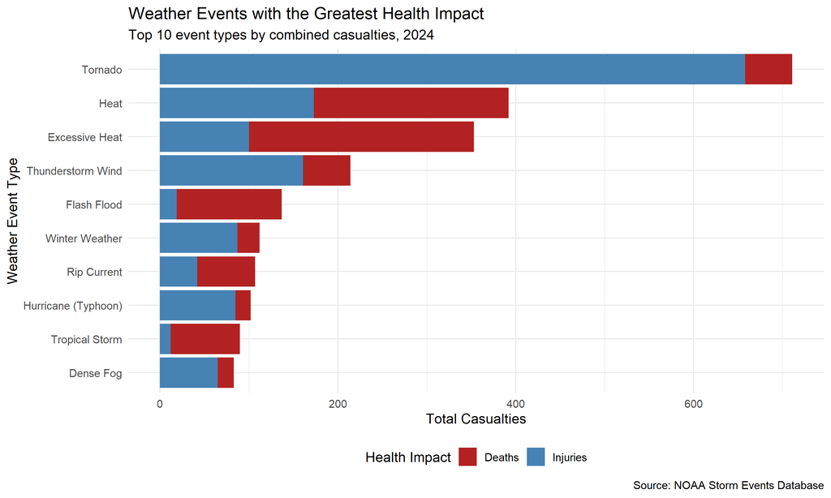

Figure 1. Top 10 weather event types by combined population health impact in 2024.

The results indicate that Excessive Heat was the leading cause of weather-related fatalities, accounting for 253 reported deaths.

The leading cause of weather-related injuries was Tornado, accounting for 658 reported injuries.

When deaths and injuries were combined, Tornado had the greatest overall population health impact, with 711 reported casualties.

This event type accounted for approximately 23.85% of all reported weather-related casualties during 2024.

These findings demonstrate the importance of evaluating both fatalities and injuries when assessing the public health consequences of severe weather. An event type that causes the most fatalities does not necessarily cause the most injuries.

The results may help emergency management agencies and public health officials identify priority areas for preparedness, public awareness, and risk mitigation.

### 3.2 Research Question 2: Geographic Analysis

**How are weather events distributed geographically, and which weather event types are most frequent across geographic areas?**

Weather events were grouped by geographic area and event type to identify differences in event frequency and population health impacts across the United States and other geographic areas represented in the NOAA database.

The analysis identified the geographic areas with the highest number of weather events, fatalities, injuries, and combined casualties.

```r
geographic_results <- data.frame(
  Measurement = c(
    "Highest weather event frequency",
    "Most weather-related deaths",
    "Most weather-related injuries",
    "Greatest combined health impact"
  ),
  Geographic_Area = c(
    top_state_events$STATE[1],
    top_state_deaths$STATE[1],
    top_state_injuries$STATE[1],
    top_state_casualties$STATE[1]
  ),
  Total = c(
    top_state_events$TOTAL_EVENTS[1],
    top_state_deaths$TOTAL_DEATHS[1],
    top_state_injuries$TOTAL_INJURIES[1],
    top_state_casualties$TOTAL_CASUALTIES[1]
  )
)

knitr::kable(
  geographic_results,
  caption = "Leading geographic areas by weather event frequency and population health impact",
  format.args = list(big.mark = ",")
)
```

Leading geographic areas by weather event frequency and population health impact

| Measurement | Geographic_Area | Total |
| --- | --- | --- |
| Highest weather event frequency | TEXAS | 5,678 |
| Most weather-related deaths | ARIZONA | 266 |
| Most weather-related injuries | TEXAS | 286 |
| Greatest combined health impact | TEXAS | 331 |

#### 3.2.1 Dominant Weather Events by Geographic Area

The most frequently recorded weather event type was identified for each geographic area. The following table presents the dominant weather event types within the ten geographic areas with the highest overall weather event frequency.

[output not shown]

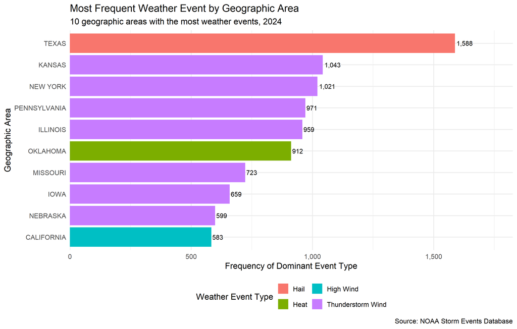

Figure 2. Most frequent weather event type within the ten geographic areas with the highest overall event frequency in 2024.

```r
knitr::kable(
  top_dominant_events %>%
    select(
      STATE,
      EVENT_TYPE,
      TOTAL_EVENTS
    ),
  col.names = c(
    "Geographic Area",
    "Dominant Weather Event",
    "Event Frequency"
  ),
  caption = "Most frequent weather event types in the ten most active geographic areas",
  format.args = list(big.mark = ",")
)
```

#### 3.2.2 Interpretation of Geographic Results

The analysis identified 68 geographic areas represented in the 2024 NOAA Storm Events Database.

Texas recorded the highest number of weather events, with 5,678 reported events. This represented approximately 8.13% of all recorded weather events.

The highest number of weather-related fatalities occurred in Arizona, with 266 reported deaths.

The highest number of weather-related injuries occurred in Texas, with 286 reported injuries.

The geographic area experiencing the greatest combined population health impact was Texas, with 331 reported casualties.

The results demonstrate that weather event frequency and population health impacts vary across geographic areas. Areas experiencing the greatest number of weather events do not necessarily experience the greatest number of fatalities.

These findings highlight the importance of geographically targeted emergency preparedness and disaster risk mitigation strategies. However, the results represent absolute event and casualty counts rather than population-adjusted risk estimates.

### 3.3 Research Question 3: Temporal Analysis

**How do weather event frequency and population health impacts vary by month and season?**

Weather events were grouped by month and season to identify temporal patterns in event frequency, fatalities, injuries, and combined casualties.

The seasons were classified as winter (December through February), spring (March through May), summer (June through August), and fall (September through November).

#### 3.3.1 Monthly Weather Event Patterns

```r
knitr::kable(
  monthly_summary,
  col.names = c(
    "Month",
    "Total Events",
    "Deaths",
    "Injuries",
    "Casualties"
  ),
  caption = "Monthly weather event frequency and population health impacts",
  format.args = list(big.mark = ",")
)
```

Monthly weather event frequency and population health impacts

| Month | Total Events | Deaths | Injuries | Casualties |
| --- | --- | --- | --- | --- |
| January | 8,493 | 106 | 225 | 331 |
| February | 3,640 | 20 | 59 | 79 |
| March | 3,874 | 18 | 112 | 130 |
| April | 5,767 | 22 | 152 | 174 |
| May | 11,183 | 85 | 390 | 475 |
| June | 8,746 | 246 | 257 | 503 |
| July | 8,996 | 222 | 106 | 328 |
| August | 8,106 | 74 | 130 | 204 |
| September | 3,467 | 220 | 192 | 412 |
| October | 1,799 | 42 | 61 | 103 |
| November | 2,691 | 43 | 53 | 96 |
| December | 3,040 | 43 | 103 | 146 |

#### 3.3.2 Seasonal Weather Event Patterns

```r
knitr::kable(
  seasonal_summary,
  col.names = c(
    "Season",
    "Total Events",
    "Deaths",
    "Injuries",
    "Casualties",
    "Event Percentage (%)"
  ),
  caption = "Seasonal weather event frequency and population health impacts",
  format.args = list(big.mark = ",")
)
```

Seasonal weather event frequency and population health impacts

| Season | Total Events | Deaths | Injuries | Casualties | Event Percentage (%) |
| --- | --- | --- | --- | --- | --- |
| Winter | 15,173 | 169 | 387 | 556 | 21.74 |
| Spring | 20,824 | 125 | 654 | 779 | 29.83 |
| Summer | 25,848 | 542 | 493 | 1,035 | 37.03 |
| Fall | 7,957 | 305 | 306 | 611 | 11.40 |

#### 3.3.3 Dominant Weather Events by Season

The most frequently recorded weather event type was identified for each season to determine how dominant weather hazards changed throughout the year.

```r
knitr::kable(
  dominant_seasonal_events %>%
    select(
      SEASON,
      EVENT_TYPE,
      TOTAL_EVENTS
    ),
  col.names = c(
    "Season",
    "Dominant Weather Event",
    "Event Frequency"
  ),
  caption = "Most frequently recorded weather event types by season",
  format.args = list(big.mark = ",")
)
```

Most frequently recorded weather event types by season

| Season | Dominant Weather Event | Event Frequency |
| --- | --- | --- |
| Winter | Winter Weather | 2,793 |
| Spring | Thunderstorm Wind | 6,427 |
| Summer | Thunderstorm Wind | 11,183 |
| Fall | Drought | 1,510 |

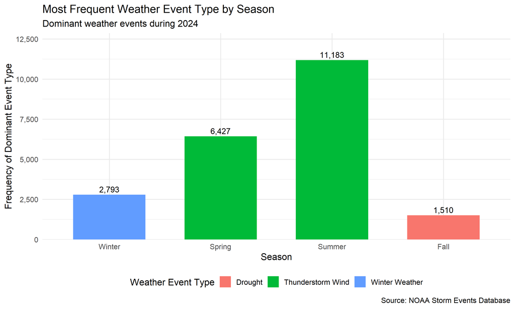

Figure 3. Most frequently recorded weather event types by season in 2024.

#### 3.3.4 Interpretation of Temporal Results

```r
peak_event_month <- monthly_summary %>%
  slice_max(TOTAL_EVENTS, n = 1, with_ties = FALSE)

peak_death_month <- monthly_summary %>%
  slice_max(TOTAL_DEATHS, n = 1, with_ties = FALSE)

peak_injury_month <- monthly_summary %>%
  slice_max(TOTAL_INJURIES, n = 1, with_ties = FALSE)

peak_event_season <- seasonal_summary %>%
  slice_max(TOTAL_EVENTS, n = 1, with_ties = FALSE)

peak_health_season <- seasonal_summary %>%
  slice_max(TOTAL_CASUALTIES, n = 1, with_ties = FALSE)
```

The month with the highest weather event frequency was May, with 11,183 recorded events.

The highest number of weather-related fatalities occurred in June, with 246 reported deaths.

The highest number of weather-related injuries occurred in May, with 390 reported injuries.

At the seasonal level, Summer experienced the greatest weather event frequency, with 25,848 recorded events, representing approximately 37.03% of all weather events during 2024.

The season experiencing the greatest combined population health impact was Summer, with 1,035 reported casualties.

Thunderstorm wind was the dominant weather event type during both spring and summer, while winter weather dominated during winter and drought dominated during fall.

These findings demonstrate that weather event frequency, event classifications, and population health consequences vary throughout the year.

Seasonal differences may assist emergency management agencies in allocating resources, developing public awareness campaigns, and preparing for periods of increased weather-related risk.

However, because this analysis examines only one calendar year, the observed temporal patterns should not be interpreted as evidence of long-term climate trends.

### 3.4 Research Question 4: Economic Consequences

**Which types of weather events have the greatest economic consequences, and how do economic impacts vary geographically and seasonally?**

Economic consequences were evaluated using reported property damage and crop damage. Both measurements were converted into numeric US dollar amounts and combined to calculate known reported economic damage.

#### 3.4.1 Overall Economic Impact

```r
economic_totals <- data.frame(
  Damage_Type = c(
    "Property Damage",
    "Crop Damage",
    "Combined Economic Damage"
  ),
  Total_USD = c(
    sum(storm_clean$PROPERTY_DAMAGE_USD, na.rm = TRUE),
    sum(storm_clean$CROP_DAMAGE_USD, na.rm = TRUE),
    sum(storm_clean$TOTAL_DAMAGE_USD, na.rm = TRUE)
  )
)

knitr::kable(
  economic_totals %>%
    mutate(
      Total_USD = scales::dollar(
        Total_USD,
        accuracy = 1
      )
    ),
  col.names = c(
    "Damage Type",
    "Known Reported Damage"
  ),
  caption = "Total reported economic damage during 2024"
)
```

Total reported economic damage during 2024

| Damage Type | Known Reported Damage |
| --- | --- |
| Property Damage | $15,741,503,630 |
| Crop Damage | $2,255,106,410 |
| Combined Economic Damage | $17,996,610,040 |

#### 3.4.2 Economic Damage by Weather Event Type

Weather event types were ranked according to their reported property damage, crop damage, and combined economic damage.

```r
knitr::kable(
  top_total_damage %>%
    select(
      EVENT_TYPE,
      PROPERTY_DAMAGE,
      CROP_DAMAGE,
      TOTAL_DAMAGE
    ) %>%
    mutate(
      across(
        c(
          PROPERTY_DAMAGE,
          CROP_DAMAGE,
          TOTAL_DAMAGE
        ),
        ~ scales::dollar(.x, accuracy = 1)
      )
    ),
  col.names = c(
    "Weather Event",
    "Property Damage",
    "Crop Damage",
    "Combined Damage"
  ),
  caption = "Top 10 weather event types by combined economic damage"
)
```

Top 10 weather event types by combined economic damage

| Weather Event | Property Damage | Crop Damage | Combined Damage |
| --- | --- | --- | --- |
| Hurricane (Typhoon) | $5,302,560,000 | $1,510,000,000 | $6,812,560,000 |
| Flash Flood | $3,143,421,200 | $101,576,500 | $3,244,997,700 |
| Tropical Storm | $1,902,007,000 | $253,006,000 | $2,155,013,000 |
| Tornado | $1,721,030,380 | $8,531,200 | $1,729,561,580 |
| Wildfire | $1,102,899,870 | $64,817,000 | $1,167,716,870 |
| Storm Surge/Tide | $870,042,000 | $0 | $870,042,000 |
| Flood | $649,031,930 | $4,905,300 | $653,937,230 |
| Thunderstorm Wind | $412,498,090 | $29,056,210 | $441,554,300 |
| Hail | $226,989,630 | $142,860,000 | $369,849,630 |
| High Wind | $127,967,600 | $112,595,200 | $240,562,800 |

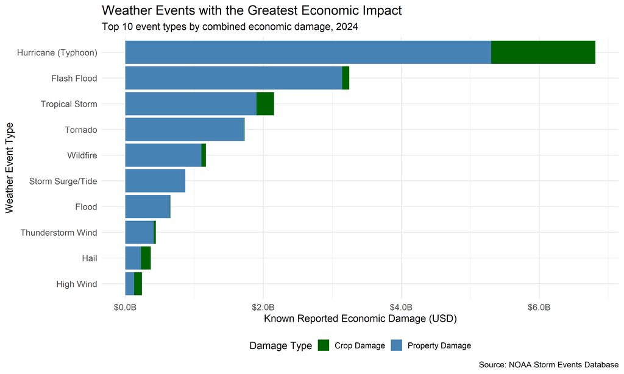

Figure 4. Weather event types with the greatest combined economic damage during 2024.

#### 3.4.3 Geographic Economic Consequences

```r
knitr::kable(
  economic_by_state %>%
    slice_max(
      TOTAL_DAMAGE,
      n = 10,
      with_ties = FALSE
    ) %>%
    select(
      STATE,
      TOTAL_DAMAGE
    ) %>%
    mutate(
      TOTAL_DAMAGE = scales::dollar(
        TOTAL_DAMAGE,
        accuracy = 1
      )
    ),
  col.names = c(
    "Geographic Area",
    "Combined Economic Damage"
  ),
  caption = "Top 10 geographic areas by reported economic damage"
)
```

Top 10 geographic areas by reported economic damage

| Geographic Area | Combined Economic Damage |
| --- | --- |
| FLORIDA | $7,600,825,250 |
| GEORGIA | $2,813,240,800 |
| NORTH CAROLINA | $2,138,196,900 |
| NEW MEXICO | $562,174,000 |
| TEXAS | $559,046,250 |
| WASHINGTON | $548,978,400 |
| SOUTH CAROLINA | $473,254,750 |
| VIRGINIA | $405,855,260 |
| OKLAHOMA | $366,341,360 |
| NEBRASKA | $363,391,500 |

#### 3.4.4 Seasonal Economic Consequences

```r
seasonal_damage_results <- economic_by_season %>%
  mutate(
    DAMAGE_PERCENTAGE =
      TOTAL_DAMAGE / sum(TOTAL_DAMAGE) * 100
  )

knitr::kable(
  seasonal_damage_results %>%
    select(
      SEASON,
      TOTAL_DAMAGE,
      DAMAGE_PERCENTAGE
    ) %>%
    mutate(
      TOTAL_DAMAGE = scales::dollar(
        TOTAL_DAMAGE,
        accuracy = 1
      ),
      DAMAGE_PERCENTAGE = round(
        DAMAGE_PERCENTAGE,
        2
      )
    ),
  col.names = c(
    "Season",
    "Combined Economic Damage",
    "Percentage of Total Damage (%)"
  ),
  caption = "Distribution of reported economic damage by season"
)
```

Distribution of reported economic damage by season

| Season | Combined Economic Damage | Percentage of Total Damage (%) |
| --- | --- | --- |
| Winter | $670,795,480 | 3.73 |
| Spring | $1,306,139,830 | 7.26 |
| Summer | $1,591,249,450 | 8.84 |
| Fall | $14,428,425,280 | 80.17 |

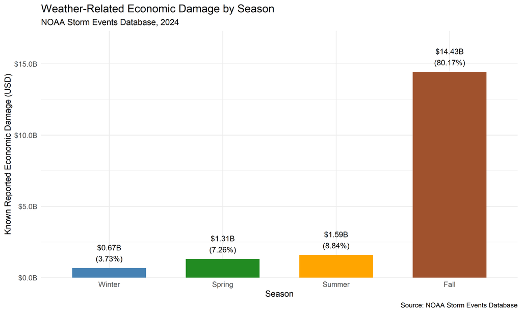

Figure 5. Seasonal distribution of known reported economic damage during 2024.

#### 3.4.5 Interpretation of Economic Results

```r
peak_property_event <- economic_by_event %>%
  slice_max(
    PROPERTY_DAMAGE,
    n = 1,
    with_ties = FALSE
  )

peak_crop_event <- economic_by_event %>%
  slice_max(
    CROP_DAMAGE,
    n = 1,
    with_ties = FALSE
  )

peak_economic_event <- economic_by_event %>%
  slice_max(
    TOTAL_DAMAGE,
    n = 1,
    with_ties = FALSE
  )

peak_economic_state <- economic_by_state %>%
  slice_max(
    TOTAL_DAMAGE,
    n = 1,
    with_ties = FALSE
  )

peak_economic_month <- economic_by_month %>%
  slice_max(
    TOTAL_DAMAGE,
    n = 1,
    with_ties = FALSE
  )

peak_economic_season <- seasonal_damage_results %>%
  slice_max(
    TOTAL_DAMAGE,
    n = 1,
    with_ties = FALSE
  )
```

The total known reported economic damage associated with weather events during 2024 was approximately $18.00 billion.

The weather event type responsible for the greatest property damage was Hurricane (Typhoon), generating approximately $5.30 billion in reported property damage.

The greatest crop damage was associated with Hurricane (Typhoon), generating approximately $1.51 billion in reported agricultural losses.

When property and crop damage were combined, Hurricane (Typhoon) generated the greatest economic impact, accounting for approximately $6.81 billion in reported damage.

Geographically, Florida experienced the greatest reported economic damage, totaling approximately $7.60 billion.

The month with the greatest economic damage was September, with approximately $11.76 billion in reported losses.

The season experiencing the greatest economic consequences was Fall, accounting for approximately 80.17% of all known reported economic damage.

These findings demonstrate that the most frequently recorded weather events are not necessarily those responsible for the greatest economic losses.

The concentration of economic damage during specific periods highlights the importance of seasonal disaster preparedness, infrastructure resilience, insurance planning, and financial risk management.

Economic damage estimates should be interpreted with caution because some weather event records contain incomplete property or crop damage information.

## 4 Appendix: Complete R Analysis Code

The following appendix contains the complete R source code used to import, integrate, clean, validate, analyze, and visualize the 2024 NOAA Storm Events datasets.

```r
# ============================================================
# FINAL COURSE PROJECT
# Analysis of NOAA Storm Database - 2024
# Author: Brian Punch-Eastman
# ============================================================

# SECTION 1: Load required packages

packages <- c("dplyr", "readr", "ggplot2", "tidyr",
              "stringr", "knitr", "rmarkdown", "scales")

for (pkg in packages) {
  if (!requireNamespace(pkg, quietly = TRUE)) {
    install.packages(pkg, repos = "https://cloud.r-project.org")
  }
}

library(dplyr)
library(readr)
library(ggplot2)
library(tidyr)
library(stringr)
library(scales)

# SECTION 2: Define dataset paths

details_file <- file.path(
  "data",
  "StormEvents_details-ftp_v1.0_d2024_c20261119.csv.gz"
)

fatalities_file <- file.path(
  "data",
  "StormEvents_fatalities-ftp_v1.0_d2024_c20261119.csv.gz"
)

locations_file <- file.path(
  "data",
  "StormEvents_locations-ftp_v1.0_d2024_c20261119.csv.gz"
)

# Verify that all files exist

stopifnot(
  file.exists(details_file),
  file.exists(fatalities_file),
  file.exists(locations_file)
)

cat("\nAll three NOAA datasets located successfully.\n")

# SECTION 3: Import raw datasets

details <- read_csv(
  details_file,
  show_col_types = FALSE
)

fatalities <- read_csv(
  fatalities_file,
  show_col_types = FALSE
)

locations <- read_csv(
  locations_file,
  show_col_types = FALSE
)

# SECTION 4: Initial data validation

cat("\n========================================\n")
cat("NOAA STORM DATABASE - INITIAL VALIDATION\n")
cat("========================================\n")

cat("\nDetails dataset dimensions:\n")
print(dim(details))

cat("\nFatalities dataset dimensions:\n")
print(dim(fatalities))

cat("\nLocations dataset dimensions:\n")
print(dim(locations))

cat("\nUnique event IDs:\n")

cat("Details:", n_distinct(details$EVENT_ID), "\n")
cat("Fatalities:", n_distinct(fatalities$EVENT_ID), "\n")
cat("Locations:", n_distinct(locations$EVENT_ID), "\n")

cat("\nRepeated event IDs:\n")

cat("Details:", sum(duplicated(details$EVENT_ID)), "\n")
cat("Fatalities:", sum(duplicated(fatalities$EVENT_ID)), "\n")
cat("Locations:", sum(duplicated(locations$EVENT_ID)), "\n")

cat("\nMissing event IDs:\n")

cat("Details:", sum(is.na(details$EVENT_ID)), "\n")
cat("Fatalities:", sum(is.na(fatalities$EVENT_ID)), "\n")
cat("Locations:", sum(is.na(locations$EVENT_ID)), "\n")

cat("\nUnmatched event IDs:\n")

cat("Fatalities:",
    sum(!fatalities$EVENT_ID %in% details$EVENT_ID), "\n")

cat("Locations:",
    sum(!locations$EVENT_ID %in% details$EVENT_ID), "\n")

cat("\nYears represented:\n")
print(unique(details$YEAR))

cat("\nNumber of geographic areas:\n")
print(n_distinct(details$STATE))

cat("\nNumber of unique event types:\n")
print(n_distinct(details$EVENT_TYPE))

cat("\nEvent types:\n")
print(sort(unique(details$EVENT_TYPE)))

cat("\nDetails column names:\n")
print(names(details))

cat("\nFatalities column names:\n")
print(names(fatalities))

cat("\nLocations column names:\n")
print(names(locations))

cat("\n========================================\n")
cat("INITIAL DATA VALIDATION COMPLETE\n")
cat("========================================\n")

# ============================================================
# SECTION 5: DATA INTEGRATION
# ============================================================

cat("\n========================================\n")
cat("DATA INTEGRATION\n")
cat("========================================\n")

# Summarize fatality records by storm event

fatality_summary <- fatalities %>%
  group_by(EVENT_ID) %>%
  summarise(
    FATALITY_RECORDS = n(),
    .groups = "drop"
  )

# Summarize location records by storm event

location_summary <- locations %>%
  group_by(EVENT_ID) %>%
  summarise(
    LOCATION_RECORDS = n(),
    .groups = "drop"
  )

# Merge summarized datasets with storm details

storm_data <- details %>%
  left_join(fatality_summary, by = "EVENT_ID") %>%
  left_join(location_summary, by = "EVENT_ID")

# Replace unmatched record counts with zero

storm_data <- storm_data %>%
  mutate(
    FATALITY_RECORDS = replace_na(FATALITY_RECORDS, 0),
    LOCATION_RECORDS = replace_na(LOCATION_RECORDS, 0)
  )

# Validate merged dataset

cat("\nOriginal storm event rows:",
    nrow(details), "\n")

cat("Integrated dataset rows:",
    nrow(storm_data), "\n")

cat("Integrated dataset columns:",
    ncol(storm_data), "\n")

cat("Unique event IDs:",
    n_distinct(storm_data$EVENT_ID), "\n")

cat("Duplicate event IDs:",
    sum(duplicated(storm_data$EVENT_ID)), "\n")

cat("Total fatality records:",
    sum(storm_data$FATALITY_RECORDS), "\n")

cat("Total location records:",
    sum(storm_data$LOCATION_RECORDS), "\n")

cat("Events with fatality records:",
    sum(storm_data$FATALITY_RECORDS > 0), "\n")

cat("Events with location records:",
    sum(storm_data$LOCATION_RECORDS > 0), "\n")

# Verify that integration did not inflate records

stopifnot(
  nrow(storm_data) == nrow(details),
  !anyDuplicated(storm_data$EVENT_ID),
  sum(storm_data$FATALITY_RECORDS) == nrow(fatalities),
  sum(storm_data$LOCATION_RECORDS) == nrow(locations)
)

# Save integrated dataset

dir.create("output", showWarnings = FALSE)

write_csv(
  storm_data,
  "output/noaa_storm_integrated_2024.csv"
)

cat("\nIntegrated dataset saved successfully.\n")

cat("\n========================================\n")
cat("DATA INTEGRATION VALIDATION: PASS\n")
cat("========================================\n")

# ============================================================
# SECTION 6: DATA CLEANING AND TRANSFORMATION
# ============================================================

cat("\n========================================\n")
cat("DATA CLEANING AND TRANSFORMATION\n")
cat("========================================\n")

# Function to convert NOAA damage values into dollars

convert_damage <- function(x) {

  x <- toupper(trimws(as.character(x)))
  x <- gsub(",", "", x)

  valid <- !is.na(x) &
    grepl("^[0-9]+(\\.[0-9]+)?[KMB]?$", x)

  result <- rep(NA_real_, length(x))
```

```r
  values <- as.numeric(
    sub("[KMB]$", "", x[valid])
  )

  multiplier <- case_when(
    grepl("K$", x[valid]) ~ 1000,
    grepl("M$", x[valid]) ~ 1000000,
    grepl("B$", x[valid]) ~ 1000000000,
    TRUE ~ 1
  )

  result[valid] <- values * multiplier

  return(result)
}

# Validate damage conversion function

stopifnot(
  convert_damage("25K") == 25000,
  convert_damage("2.5M") == 2500000,
  convert_damage("1.2B") == 1200000000,
  convert_damage("0.00K") == 0,
  is.na(convert_damage(NA)),
  is.na(convert_damage("UNKNOWN"))
)

cat("\nDamage conversion function: PASS\n")

# Clean and transform integrated dataset

storm_clean <- storm_data %>%
  mutate(

    STATE = trimws(STATE),

    EVENT_TYPE = trimws(EVENT_TYPE),

    # Calculate population health impacts

    TOTAL_DEATHS =
      DEATHS_DIRECT + DEATHS_INDIRECT,

    TOTAL_INJURIES =
      INJURIES_DIRECT + INJURIES_INDIRECT,

    TOTAL_CASUALTIES =
      TOTAL_DEATHS + TOTAL_INJURIES,

    # Convert economic damage to dollars

    PROPERTY_DAMAGE_USD =
      convert_damage(DAMAGE_PROPERTY),

    CROP_DAMAGE_USD =
      convert_damage(DAMAGE_CROPS),

    # Identify incomplete damage information

    DAMAGE_INCOMPLETE =
      is.na(PROPERTY_DAMAGE_USD) |
      is.na(CROP_DAMAGE_USD),

    # Calculate known reported economic damage

    TOTAL_DAMAGE_USD =
      coalesce(PROPERTY_DAMAGE_USD, 0) +
      coalesce(CROP_DAMAGE_USD, 0),

    # Organize months chronologically

    MONTH_NAME = factor(
      MONTH_NAME,
      levels = month.name,
      ordered = TRUE
    ),

    MONTH_NUMBER = as.integer(MONTH_NAME),

    # Assign meteorological seasons

    SEASON = case_when(
      MONTH_NUMBER %in% c(12, 1, 2) ~ "Winter",
      MONTH_NUMBER %in% c(3, 4, 5) ~ "Spring",
      MONTH_NUMBER %in% c(6, 7, 8) ~ "Summer",
      MONTH_NUMBER %in% c(9, 10, 11) ~ "Fall",
      TRUE ~ NA_character_
    ),

    SEASON = factor(
      SEASON,
      levels = c("Winter", "Spring", "Summer", "Fall")
    )
  )

# ============================================================
# SECTION 7: CLEANED DATA VALIDATION
# ============================================================

cat("\n========================================\n")
cat("CLEANED DATASET VALIDATION\n")
cat("========================================\n")

cat("\nCleaned dataset rows:",
    nrow(storm_clean), "\n")

cat("Cleaned dataset columns:",
    ncol(storm_clean), "\n")

cat("Duplicate event IDs:",
    sum(duplicated(storm_clean$EVENT_ID)), "\n")

# Missing values in analytical variables

cat("\nMissing values in analytical variables:\n")

analysis_columns <- c(
  "EVENT_ID",
  "STATE",
  "EVENT_TYPE",
  "TOTAL_DEATHS",
  "TOTAL_INJURIES",
  "TOTAL_CASUALTIES",
  "PROPERTY_DAMAGE_USD",
  "CROP_DAMAGE_USD",
  "TOTAL_DAMAGE_USD",
  "MONTH_NUMBER",
  "SEASON"
)

print(
  colSums(is.na(storm_clean[, analysis_columns]))
)

# Identify unrecognized damage values

cat("\nUnrecognized property damage values:\n")

print(
  unique(
    storm_clean$DAMAGE_PROPERTY[
      is.na(storm_clean$PROPERTY_DAMAGE_USD) &
      !is.na(storm_clean$DAMAGE_PROPERTY)
    ]
  )
)

cat("\nUnrecognized crop damage values:\n")

print(
  unique(
    storm_clean$DAMAGE_CROPS[
      is.na(storm_clean$CROP_DAMAGE_USD) &
      !is.na(storm_clean$DAMAGE_CROPS)
    ]
  )
)

cat("\nEvents with incomplete damage information:",
    sum(storm_clean$DAMAGE_INCOMPLETE), "\n")

# Population health totals

cat("\n========================================\n")
cat("PRELIMINARY POPULATION HEALTH RESULTS\n")
cat("========================================\n")

cat("\nDirect deaths:",
    sum(storm_clean$DEATHS_DIRECT, na.rm = TRUE), "\n")

cat("Indirect deaths:",
    sum(storm_clean$DEATHS_INDIRECT, na.rm = TRUE), "\n")

cat("Total deaths:",
    sum(storm_clean$TOTAL_DEATHS, na.rm = TRUE), "\n")

cat("Direct injuries:",
    sum(storm_clean$INJURIES_DIRECT, na.rm = TRUE), "\n")

cat("Indirect injuries:",
    sum(storm_clean$INJURIES_INDIRECT, na.rm = TRUE), "\n")

cat("Total injuries:",
    sum(storm_clean$TOTAL_INJURIES, na.rm = TRUE), "\n")

cat("Total casualties:",
    sum(storm_clean$TOTAL_CASUALTIES, na.rm = TRUE), "\n")

cat("Fatality detail records:",
    sum(storm_clean$FATALITY_RECORDS), "\n")

# Compare reported deaths with fatality records

cat("Events with differing death and fatality counts:",
    sum(
      storm_clean$TOTAL_DEATHS !=
        storm_clean$FATALITY_RECORDS,
      na.rm = TRUE
    ), "\n")

# Economic damage totals

cat("\n========================================\n")
cat("PRELIMINARY ECONOMIC DAMAGE RESULTS\n")
cat("========================================\n")

cat("\nReported property damage:",
    dollar(sum(
      storm_clean$PROPERTY_DAMAGE_USD,
      na.rm = TRUE
    )), "\n")

cat("Reported crop damage:",
    dollar(sum(
      storm_clean$CROP_DAMAGE_USD,
      na.rm = TRUE
    )), "\n")

cat("Total known reported economic damage:",
    dollar(sum(
      storm_clean$TOTAL_DAMAGE_USD,
      na.rm = TRUE
    )), "\n")

# Monthly distribution

cat("\nStorm events by month:\n")

print(table(storm_clean$MONTH_NAME, useNA = "ifany"))

# Seasonal distribution

cat("\nStorm events by season:\n")

print(table(storm_clean$SEASON, useNA = "ifany"))

# Final integrity checks

stopifnot(
  nrow(storm_clean) == nrow(details),
  !anyDuplicated(storm_clean$EVENT_ID),
  all(storm_clean$YEAR == 2024),
  sum(is.na(storm_clean$MONTH_NUMBER)) == 0,
  sum(is.na(storm_clean$SEASON)) == 0,
  all(storm_clean$TOTAL_DAMAGE_USD >= 0),
  sum(storm_clean$FATALITY_RECORDS) == nrow(fatalities),
  sum(storm_clean$LOCATION_RECORDS) == nrow(locations)
)

# Save cleaned dataset

write_csv(
  storm_clean,
  "output/noaa_storm_clean_2024.csv"
)

cat("\nCleaned dataset saved successfully.\n")

cat("\n========================================\n")
cat("DATA CLEANING VALIDATION: PASS\n")
cat("========================================\n")

# ============================================================
# SECTION 8: RESEARCH QUESTION 1 - POPULATION HEALTH
# ============================================================
```

```r
cat("\n========================================\n")
cat("RESEARCH QUESTION 1 - POPULATION HEALTH\n")
cat("========================================\n")

dir.create("figures", showWarnings = FALSE)

# Document fatality discrepancies

fatality_discrepancies <- storm_clean %>%
  filter(TOTAL_DEATHS != FATALITY_RECORDS) %>%
  select(
    EVENT_ID,
    STATE,
    EVENT_TYPE,
    MONTH_NAME,
    DEATHS_DIRECT,
    DEATHS_INDIRECT,
    TOTAL_DEATHS,
    FATALITY_RECORDS
  ) %>%
  mutate(
    DIFFERENCE = FATALITY_RECORDS - TOTAL_DEATHS
  )

cat("\nFatality reconciliation:\n")

print(fatality_discrepancies, width = Inf)

write_csv(
  fatality_discrepancies,
  "output/fatality_reconciliation.csv"
)

# Summarize health impacts by event type

health_summary <- storm_clean %>%
  group_by(EVENT_TYPE) %>%
  summarise(
    TOTAL_EVENTS = n(),
    DIRECT_DEATHS = sum(DEATHS_DIRECT),
    INDIRECT_DEATHS = sum(DEATHS_INDIRECT),
    TOTAL_DEATHS = sum(TOTAL_DEATHS),
    DIRECT_INJURIES = sum(INJURIES_DIRECT),
    INDIRECT_INJURIES = sum(INJURIES_INDIRECT),
    TOTAL_INJURIES = sum(TOTAL_INJURIES),
    TOTAL_CASUALTIES = sum(TOTAL_CASUALTIES),
    .groups = "drop"
  ) %>%
  mutate(
    CASUALTIES_PER_100_EVENTS =
      round(TOTAL_CASUALTIES / TOTAL_EVENTS * 100, 2)
  ) %>%
  arrange(desc(TOTAL_CASUALTIES))

# Validate population health summary

stopifnot(
  nrow(health_summary) == 50,
  sum(health_summary$TOTAL_EVENTS) == nrow(storm_clean),
  sum(health_summary$TOTAL_DEATHS) ==
    sum(storm_clean$TOTAL_DEATHS),
  sum(health_summary$TOTAL_INJURIES) ==
    sum(storm_clean$TOTAL_INJURIES),
  sum(health_summary$TOTAL_CASUALTIES) ==
    sum(storm_clean$TOTAL_CASUALTIES)
)

# Top 10 event types by deaths

top_deaths <- health_summary %>%
  arrange(desc(TOTAL_DEATHS), EVENT_TYPE) %>%
  slice_head(n = 10)

cat("\nTOP 10 EVENT TYPES BY DEATHS:\n")

print(
  top_deaths %>%
    select(EVENT_TYPE, TOTAL_EVENTS, TOTAL_DEATHS),
  n = 10
)

# Top 10 event types by injuries

top_injuries <- health_summary %>%
  arrange(desc(TOTAL_INJURIES), EVENT_TYPE) %>%
  slice_head(n = 10)

cat("\nTOP 10 EVENT TYPES BY INJURIES:\n")

print(
  top_injuries %>%
    select(EVENT_TYPE, TOTAL_EVENTS, TOTAL_INJURIES),
  n = 10
)

# Top 10 event types by casualties

top_casualties <- health_summary %>%
  slice_head(n = 10)

cat("\nTOP 10 EVENT TYPES BY TOTAL CASUALTIES:\n")

print(
  top_casualties %>%
    select(
      EVENT_TYPE,
      TOTAL_DEATHS,
      TOTAL_INJURIES,
      TOTAL_CASUALTIES
    ),
  n = 10
)

# Save population health summary

write_csv(
  health_summary,
  "output/population_health_by_event.csv"
)

# ============================================================
# FIGURE 1: TOP 10 EVENT TYPES BY DEATHS
# ============================================================

plot_deaths <- ggplot(
  top_deaths,
  aes(
    x = reorder(EVENT_TYPE, TOTAL_DEATHS),
    y = TOTAL_DEATHS
  )
) +
  geom_col(fill = "firebrick") +
  geom_text(
    aes(label = TOTAL_DEATHS),
    hjust = -0.15,
    size = 3.5
  ) +
  coord_flip() +
  scale_y_continuous(
    expand = expansion(mult = c(0, 0.15))
  ) +
  labs(
    title = "Top 10 Weather Event Types by Fatalities",
    subtitle = "NOAA Storm Events Database, 2024",
    x = "Weather Event Type",
    y = "Total Deaths",
    caption = "Source: NOAA Storm Events Database"
  ) +
  theme_minimal(base_size = 12)

ggsave(
  "figures/01_top_deaths.png",
  plot_deaths,
  width = 10,
  height = 6,
  dpi = 300
)

# ============================================================
# FIGURE 2: TOP 10 EVENT TYPES BY INJURIES
# ============================================================

plot_injuries <- ggplot(
  top_injuries,
  aes(
    x = reorder(EVENT_TYPE, TOTAL_INJURIES),
    y = TOTAL_INJURIES
  )
) +
  geom_col(fill = "steelblue") +
  geom_text(
    aes(label = TOTAL_INJURIES),
    hjust = -0.15,
    size = 3.5
  ) +
  coord_flip() +
  scale_y_continuous(
    expand = expansion(mult = c(0, 0.15))
  ) +
  labs(
    title = "Top 10 Weather Event Types by Injuries",
    subtitle = "NOAA Storm Events Database, 2024",
    x = "Weather Event Type",
    y = "Total Injuries",
    caption = "Source: NOAA Storm Events Database"
  ) +
  theme_minimal(base_size = 12)

ggsave(
  "figures/02_top_injuries.png",
  plot_injuries,
  width = 10,
  height = 6,
  dpi = 300
)

# ============================================================
# FIGURE 3: COMBINED POPULATION HEALTH IMPACT
# ============================================================

health_long <- top_casualties %>%
  select(
    EVENT_TYPE,
    TOTAL_DEATHS,
    TOTAL_INJURIES,
    TOTAL_CASUALTIES
  ) %>%
  pivot_longer(
    cols = c(TOTAL_DEATHS, TOTAL_INJURIES),
    names_to = "IMPACT_TYPE",
    values_to = "COUNT"
  ) %>%
  mutate(
    IMPACT_TYPE = recode(
      IMPACT_TYPE,
      TOTAL_DEATHS = "Deaths",
      TOTAL_INJURIES = "Injuries"
    )
  )

plot_casualties <- ggplot(
  health_long,
  aes(
    x = reorder(EVENT_TYPE, TOTAL_CASUALTIES),
    y = COUNT,
    fill = IMPACT_TYPE
  )
) +
  geom_col() +
  coord_flip() +
  scale_fill_manual(
    values = c(
      "Deaths" = "firebrick",
      "Injuries" = "steelblue"
    )
  ) +
  labs(
    title = "Weather Events with the Greatest Health Impact",
    subtitle = "Top 10 event types by combined casualties, 2024",
    x = "Weather Event Type",
    y = "Total Casualties",
    fill = "Health Impact",
    caption = "Source: NOAA Storm Events Database"
  ) +
  theme_minimal(base_size = 12) +
  theme(legend.position = "bottom")

ggsave(
  "figures/03_combined_health_impact.png",
  plot_casualties,
  width = 10,
  height = 6,
  dpi = 300
)

# ============================================================
# FIGURE 4: DIRECT AND INDIRECT DEATHS
# ============================================================

death_comparison <- top_deaths %>%
  select(
    EVENT_TYPE,
    TOTAL_DEATHS,
    DIRECT_DEATHS,
    INDIRECT_DEATHS
  ) %>%
  pivot_longer(
    cols = c(DIRECT_DEATHS, INDIRECT_DEATHS),
    names_to = "DEATH_TYPE",
    values_to = "COUNT"
  ) %>%
  mutate(
    DEATH_TYPE = recode(
      DEATH_TYPE,
      DIRECT_DEATHS = "Direct",
      INDIRECT_DEATHS = "Indirect"
    )
  )
```

```r
plot_death_comparison <- ggplot(
  death_comparison,
  aes(
    x = reorder(EVENT_TYPE, TOTAL_DEATHS),
    y = COUNT,
    fill = DEATH_TYPE
  )
) +
  geom_col() +
  coord_flip() +
  scale_fill_manual(
    values = c(
      "Direct" = "firebrick",
      "Indirect" = "orange"
    )
  ) +
  labs(
    title = "Direct and Indirect Weather-Related Deaths",
    subtitle = "Top 10 event types by fatalities, 2024",
    x = "Weather Event Type",
    y = "Number of Deaths",
    fill = "Death Type",
    caption = "Source: NOAA Storm Events Database"
  ) +
  theme_minimal(base_size = 12) +
  theme(legend.position = "bottom")

ggsave(
  "figures/04_direct_indirect_deaths.png",
  plot_death_comparison,
  width = 10,
  height = 6,
  dpi = 300
)

# ============================================================
# RESEARCH QUESTION 1 - FINAL RESULTS
# ============================================================

cat("\n========================================\n")
cat("RESEARCH QUESTION 1 - FINAL RESULTS\n")
cat("========================================\n")

cat("\nLeading cause of weather-related deaths:",
    top_deaths$EVENT_TYPE[1], "\n")

cat("Total deaths:",
    top_deaths$TOTAL_DEATHS[1], "\n")

cat("\nLeading cause of weather-related injuries:",
    top_injuries$EVENT_TYPE[1], "\n")

cat("Total injuries:",
    top_injuries$TOTAL_INJURIES[1], "\n")

cat("\nGreatest combined population health impact:",
    top_casualties$EVENT_TYPE[1], "\n")

cat("Total casualties:",
    top_casualties$TOTAL_CASUALTIES[1], "\n")

cat("\nPercentage of all casualties:",
    round(
      top_casualties$TOTAL_CASUALTIES[1] /
        sum(health_summary$TOTAL_CASUALTIES) * 100,
      2
    ), "%\n")

# Verify output files

health_files <- c(
  "output/fatality_reconciliation.csv",
  "output/population_health_by_event.csv",
  "figures/01_top_deaths.png",
  "figures/02_top_injuries.png",
  "figures/03_combined_health_impact.png",
  "figures/04_direct_indirect_deaths.png"
)

stopifnot(all(file.exists(health_files)))

cat("\nAll six research output files saved successfully.\n")

cat("\n========================================\n")
cat("RESEARCH QUESTION 1 VALIDATION: PASS\n")
cat("========================================\n")


# ============================================================
# SECTION 9: GEOGRAPHIC DISTRIBUTION OF WEATHER EVENTS
# Research Question 2
# ============================================================

cat("\n========================================\n")
cat("GEOGRAPHIC DISTRIBUTION ANALYSIS\n")
cat("========================================\n")

# Summarize weather events by geographic area

state_summary <- storm_clean %>%
  group_by(STATE) %>%
  summarise(
    TOTAL_EVENTS = n(),
    TOTAL_DEATHS = sum(TOTAL_DEATHS, na.rm = TRUE),
    TOTAL_INJURIES = sum(TOTAL_INJURIES, na.rm = TRUE),
    TOTAL_CASUALTIES = sum(TOTAL_CASUALTIES, na.rm = TRUE),
    TOTAL_DAMAGE_USD = sum(TOTAL_DAMAGE_USD, na.rm = TRUE),
    .groups = "drop"
  ) %>%
  arrange(desc(TOTAL_EVENTS))

# Identify top 10 geographic areas by event frequency

top_state_events <- state_summary %>%
  slice_max(TOTAL_EVENTS, n = 10, with_ties = FALSE)

# Identify top 10 geographic areas by fatalities

top_state_deaths <- state_summary %>%
  slice_max(TOTAL_DEATHS, n = 10, with_ties = FALSE)

# Identify top 10 geographic areas by injuries

top_state_injuries <- state_summary %>%
  slice_max(TOTAL_INJURIES, n = 10, with_ties = FALSE)

# Identify top 10 geographic areas by combined casualties

top_state_casualties <- state_summary %>%
  slice_max(TOTAL_CASUALTIES, n = 10, with_ties = FALSE)

# Summarize weather event types by geographic area

state_event_types <- storm_clean %>%
  group_by(STATE, EVENT_TYPE) %>%
  summarise(
    TOTAL_EVENTS = n(),
    TOTAL_DEATHS = sum(TOTAL_DEATHS, na.rm = TRUE),
    TOTAL_INJURIES = sum(TOTAL_INJURIES, na.rm = TRUE),
    .groups = "drop"
  )

# Identify most frequent weather event type
# in each geographic area

dominant_state_events <- state_event_types %>%
  arrange(STATE, desc(TOTAL_EVENTS), EVENT_TYPE) %>%
  group_by(STATE) %>%
  slice_head(n = 1) %>%
  ungroup()

# Limit dominant event analysis to top 10 areas

top_dominant_events <- dominant_state_events %>%
  filter(STATE %in% top_state_events$STATE) %>%
  arrange(desc(TOTAL_EVENTS))

# Display analytical results

cat("\nTop 10 geographic areas by weather events:\n")
print(top_state_events, n = 10, width = Inf)

cat("\nTop 10 geographic areas by fatalities:\n")
print(top_state_deaths, n = 10, width = Inf)

cat("\nTop 10 geographic areas by injuries:\n")
print(top_state_injuries, n = 10, width = Inf)

cat("\nTop 10 geographic areas by combined casualties:\n")
print(top_state_casualties, n = 10, width = Inf)

cat("\nMost frequent event types in top 10 areas:\n")
print(top_dominant_events, n = 10, width = Inf)

# Save geographic summary tables

write_csv(
  state_summary,
  "output/geographic_summary.csv"
)

write_csv(
  state_event_types,
  "output/geographic_event_types.csv"
)

write_csv(
  dominant_state_events,
  "output/dominant_geographic_events.csv"
)

write_csv(
  top_state_casualties,
  "output/top_geographic_casualties.csv"
)

# ============================================================
# FIGURE 05: TOP GEOGRAPHIC AREAS BY EVENT FREQUENCY
# ============================================================

plot05 <- ggplot(
  top_state_events,
  aes(
    x = reorder(STATE, TOTAL_EVENTS),
    y = TOTAL_EVENTS
  )
) +
  geom_col(fill = "darkgreen") +
  geom_text(
    aes(label = scales::comma(TOTAL_EVENTS)),
    hjust = -0.1,
    size = 3.5
  ) +
  coord_flip() +
  scale_y_continuous(
    labels = scales::comma,
    expand = expansion(mult = c(0, 0.15))
  ) +
  labs(
    title = "Top 10 Geographic Areas by Weather Events",
    subtitle = "NOAA Storm Events Database, 2024",
    x = "Geographic Area",
    y = "Total Weather Events",
    caption = "Source: NOAA Storm Events Database"
  ) +
  theme_minimal(base_size = 13)

ggsave(
  "figures/05_geographic_event_frequency.png",
  plot = plot05,
  width = 10,
  height = 6,
  dpi = 300
)
```

```r
cat("\nFigure 05 saved successfully.\n")

# ============================================================
# FIGURE 06: TOP GEOGRAPHIC AREAS BY FATALITIES
# ============================================================

plot06 <- ggplot(
  top_state_deaths,
  aes(
    x = reorder(STATE, TOTAL_DEATHS),
    y = TOTAL_DEATHS
  )
) +
  geom_col(fill = "firebrick") +
  geom_text(
    aes(label = scales::comma(TOTAL_DEATHS)),
    hjust = -0.1,
    size = 3.5
  ) +
  coord_flip() +
  scale_y_continuous(
    labels = scales::comma,
    expand = expansion(mult = c(0, 0.15))
  ) +
  labs(
    title = "Top 10 Geographic Areas by Weather-Related Deaths",
    subtitle = "NOAA Storm Events Database, 2024",
    x = "Geographic Area",
    y = "Total Deaths",
    caption = "Source: NOAA Storm Events Database"
  ) +
  theme_minimal(base_size = 13)

ggsave(
  "figures/06_geographic_fatalities.png",
  plot = plot06,
  width = 10,
  height = 6,
  dpi = 300
)

cat("Figure 06 saved successfully.\n")

# ============================================================
# FIGURE 07: TOP GEOGRAPHIC AREAS BY INJURIES
# ============================================================

plot07 <- ggplot(
  top_state_injuries,
  aes(
    x = reorder(STATE, TOTAL_INJURIES),
    y = TOTAL_INJURIES
  )
) +
  geom_col(fill = "steelblue") +
  geom_text(
    aes(label = scales::comma(TOTAL_INJURIES)),
    hjust = -0.1,
    size = 3.5
  ) +
  coord_flip() +
  scale_y_continuous(
    labels = scales::comma,
    expand = expansion(mult = c(0, 0.15))
  ) +
  labs(
    title = "Top 10 Geographic Areas by Weather-Related Injuries",
    subtitle = "NOAA Storm Events Database, 2024",
    x = "Geographic Area",
    y = "Total Injuries",
    caption = "Source: NOAA Storm Events Database"
  ) +
  theme_minimal(base_size = 13)

ggsave(
  "figures/07_geographic_injuries.png",
  plot = plot07,
  width = 10,
  height = 6,
  dpi = 300
)

cat("Figure 07 saved successfully.\n")

# ============================================================
# FIGURE 08: DOMINANT WEATHER EVENTS BY GEOGRAPHIC AREA
# ============================================================

plot08 <- ggplot(
  top_dominant_events,
  aes(
    x = reorder(STATE, TOTAL_EVENTS),
    y = TOTAL_EVENTS,
    fill = EVENT_TYPE
  )
) +
  geom_col() +
  geom_text(
    aes(label = scales::comma(TOTAL_EVENTS)),
    hjust = -0.1,
    size = 3.5
  ) +
  coord_flip() +
  scale_y_continuous(
    labels = scales::comma,
    expand = expansion(mult = c(0, 0.15))
  ) +
  labs(
    title = "Most Frequent Weather Event by Geographic Area",
    subtitle = "10 geographic areas with the most weather events, 2024",
    x = "Geographic Area",
    y = "Frequency of Dominant Event Type",
    fill = "Weather Event Type",
    caption = "Source: NOAA Storm Events Database"
  ) +
  theme_minimal(base_size = 13) +
  theme(legend.position = "bottom") +
  guides(fill = guide_legend(nrow = 2))

ggsave(
  "figures/08_dominant_geographic_events.png",
  plot = plot08,
  width = 11,
  height = 7,
  dpi = 300
)

cat("Figure 08 saved successfully.\n")

# ============================================================
# GEOGRAPHIC ANALYSIS VALIDATION
# ============================================================

cat("\n========================================\n")
cat("GEOGRAPHIC ANALYSIS VALIDATION\n")
cat("========================================\n")

cat("Geographic areas:", nrow(state_summary), "\n")
cat("Total weather events:", sum(state_summary$TOTAL_EVENTS), "\n")
cat("Total deaths:", sum(state_summary$TOTAL_DEATHS), "\n")
cat("Total injuries:", sum(state_summary$TOTAL_INJURIES), "\n")
cat("Total casualties:", sum(state_summary$TOTAL_CASUALTIES), "\n")

stopifnot(
  nrow(state_summary) == 68,
  sum(state_summary$TOTAL_EVENTS) == nrow(storm_clean),
  sum(state_summary$TOTAL_DEATHS) == sum(storm_clean$TOTAL_DEATHS),
  sum(state_summary$TOTAL_INJURIES) == sum(storm_clean$TOTAL_INJURIES),
  sum(state_summary$TOTAL_CASUALTIES) == sum(storm_clean$TOTAL_CASUALTIES),
  sum(state_event_types$TOTAL_EVENTS) == nrow(storm_clean),
  nrow(dominant_state_events) == nrow(state_summary),
  nrow(top_dominant_events) == 10
)

stopifnot(
  all(file.exists(c(
    "figures/05_geographic_event_frequency.png",
    "figures/06_geographic_fatalities.png",
    "figures/07_geographic_injuries.png",
    "figures/08_dominant_geographic_events.png",
    "output/geographic_summary.csv",
    "output/geographic_event_types.csv",
    "output/dominant_geographic_events.csv",
    "output/top_geographic_casualties.csv"
  )))
)

cat("\nAll geographic summary tables saved successfully.\n")
cat("All four geographic visualizations saved successfully.\n")

cat("\n========================================\n")
cat("GEOGRAPHIC ANALYSIS VALIDATION: PASS\n")
cat("========================================\n")


# ============================================================
# STEP 7: SEASONAL PATTERNS ANALYSIS
# ============================================================

cat("\n========================================\n")
cat("SEASONAL PATTERNS ANALYSIS\n")
cat("========================================\n")

library(dplyr)
library(tidyr)
library(ggplot2)
library(scales)
library(readr)

dir.create("figures", showWarnings = FALSE)
dir.create("output", showWarnings = FALSE)

# ------------------------------------------------------------
# 7.1 Load cleaned dataset
# ------------------------------------------------------------

clean_files <- list.files(
  "output",
  pattern = "clean.*\\.csv$",
  full.names = TRUE,
  ignore.case = TRUE
)

if (length(clean_files) != 1) {
  stop("Expected exactly one cleaned CSV in the output folder.")
}

season_data <- read_csv(
  clean_files[1],
  show_col_types = FALSE
)

season_data <- season_data %>%
  mutate(
    MONTH_NAME = factor(
      MONTH_NAME,
      levels = month.name
    ),
    SEASON = factor(
      SEASON,
      levels = c("Winter", "Spring", "Summer", "Fall")
    )
  )

# ------------------------------------------------------------
# 7.2 Monthly summary
# ------------------------------------------------------------
```

```r
monthly_summary <- season_data %>%
  group_by(MONTH_NAME) %>%
  summarise(
    TOTAL_EVENTS = n(),
    TOTAL_DEATHS = sum(TOTAL_DEATHS, na.rm = TRUE),
    TOTAL_INJURIES = sum(TOTAL_INJURIES, na.rm = TRUE),
    TOTAL_CASUALTIES = sum(TOTAL_CASUALTIES, na.rm = TRUE),
    .groups = "drop"
  ) %>%
  arrange(MONTH_NAME)

print(monthly_summary, n = 12)

write_csv(
  monthly_summary,
  "output/monthly_weather_summary.csv"
)

# ------------------------------------------------------------
# 7.3 Seasonal summary
# ------------------------------------------------------------

seasonal_summary <- season_data %>%
  group_by(SEASON) %>%
  summarise(
    TOTAL_EVENTS = n(),
    TOTAL_DEATHS = sum(TOTAL_DEATHS, na.rm = TRUE),
    TOTAL_INJURIES = sum(TOTAL_INJURIES, na.rm = TRUE),
    TOTAL_CASUALTIES = sum(TOTAL_CASUALTIES, na.rm = TRUE),
    .groups = "drop"
  ) %>%
  mutate(
    EVENT_PERCENTAGE = round(
      TOTAL_EVENTS / sum(TOTAL_EVENTS) * 100, 2
    )
  )

print(seasonal_summary)

write_csv(
  seasonal_summary,
  "output/seasonal_weather_summary.csv"
)

# ------------------------------------------------------------
# 7.4 Weather event types by season
# ------------------------------------------------------------

seasonal_event_types <- season_data %>%
  group_by(SEASON, EVENT_TYPE) %>%
  summarise(
    TOTAL_EVENTS = n(),
    TOTAL_DEATHS = sum(TOTAL_DEATHS, na.rm = TRUE),
    TOTAL_INJURIES = sum(TOTAL_INJURIES, na.rm = TRUE),
    .groups = "drop"
  ) %>%
  arrange(SEASON, desc(TOTAL_EVENTS))

write_csv(
  seasonal_event_types,
  "output/seasonal_event_types.csv"
)

dominant_seasonal_events <- seasonal_event_types %>%
  group_by(SEASON) %>%
  slice_max(
    order_by = TOTAL_EVENTS,
    n = 1,
    with_ties = FALSE
  ) %>%
  ungroup()

cat("\nMost frequent weather event by season:\n")
print(dominant_seasonal_events)

write_csv(
  dominant_seasonal_events,
  "output/dominant_seasonal_events.csv"
)

# ------------------------------------------------------------
# FIGURE 09: Monthly weather event frequency
# ------------------------------------------------------------

plot09 <- ggplot(
  monthly_summary,
  aes(x = MONTH_NAME, y = TOTAL_EVENTS)
) +
  geom_col(fill = "darkgreen") +
  geom_text(
    aes(label = comma(TOTAL_EVENTS)),
    vjust = -0.4,
    size = 3.5
  ) +
  scale_y_continuous(
    labels = comma,
    expand = expansion(mult = c(0, 0.12))
  ) +
  labs(
    title = "Monthly Weather Event Frequency",
    subtitle = "NOAA Storm Events Database, 2024",
    x = "Month",
    y = "Total Weather Events",
    caption = "Source: NOAA Storm Events Database"
  ) +
  theme_minimal(base_size = 13) +
  theme(
    axis.text.x = element_text(
      angle = 45,
      hjust = 1
    )
  )

ggsave(
  "figures/09_monthly_event_frequency.png",
  plot09,
  width = 10,
  height = 6,
  dpi = 300
)

# ------------------------------------------------------------
# FIGURE 10: Seasonal weather event frequency
# ------------------------------------------------------------

plot10 <- ggplot(
  seasonal_summary,
  aes(x = SEASON, y = TOTAL_EVENTS, fill = SEASON)
) +
  geom_col(width = 0.65) +
  geom_text(
    aes(
      label = paste0(
        comma(TOTAL_EVENTS),
        "\n(",
        EVENT_PERCENTAGE,
        "%)"
      )
    ),
    vjust = -0.3,
    size = 4
  ) +
  scale_fill_manual(
    values = c(
      "Winter" = "steelblue",
      "Spring" = "forestgreen",
      "Summer" = "orange",
      "Fall" = "sienna"
    )
  ) +
  scale_y_continuous(
    labels = comma,
    expand = expansion(mult = c(0, 0.18))
  ) +
  labs(
    title = "Weather Event Frequency by Season",
    subtitle = "NOAA Storm Events Database, 2024",
    x = "Season",
    y = "Total Weather Events",
    caption = "Source: NOAA Storm Events Database"
  ) +
  theme_minimal(base_size = 13) +
  theme(legend.position = "none")

ggsave(
  "figures/10_seasonal_event_frequency.png",
  plot10,
  width = 10,
  height = 6,
  dpi = 300
)

# ------------------------------------------------------------
# FIGURE 11: Monthly deaths and injuries
# ------------------------------------------------------------

monthly_health <- monthly_summary %>%
  select(
    MONTH_NAME,
    Deaths = TOTAL_DEATHS,
    Injuries = TOTAL_INJURIES
  ) %>%
  pivot_longer(
    cols = c(Deaths, Injuries),
    names_to = "HEALTH_IMPACT",
    values_to = "TOTAL"
  )

plot11 <- ggplot(
  monthly_health,
  aes(
    x = MONTH_NAME,
    y = TOTAL,
    fill = HEALTH_IMPACT
  )
) +
  geom_col(position = "dodge") +
  scale_fill_manual(
    values = c(
      "Deaths" = "firebrick",
      "Injuries" = "steelblue"
    )
  ) +
  scale_y_continuous(labels = comma) +
  labs(
    title = "Monthly Weather-Related Deaths and Injuries",
    subtitle = "Population health impacts during 2024",
    x = "Month",
    y = "Number of Deaths and Injuries",
    fill = "Health Impact",
    caption = "Source: NOAA Storm Events Database"
  ) +
  theme_minimal(base_size = 13) +
  theme(
    axis.text.x = element_text(
      angle = 45,
      hjust = 1
    ),
    legend.position = "bottom"
  )

ggsave(
  "figures/11_monthly_health_impact.png",
  plot11,
  width = 10,
  height = 6,
  dpi = 300
)

# ------------------------------------------------------------
# FIGURE 12: Most frequent weather event by season
# ------------------------------------------------------------

plot12 <- ggplot(
  dominant_seasonal_events,
  aes(
    x = SEASON,
    y = TOTAL_EVENTS,
    fill = EVENT_TYPE
  )
) +
  geom_col(width = 0.65) +
  geom_text(
    aes(label = comma(TOTAL_EVENTS)),
    vjust = -0.4,
    size = 4
  ) +
  scale_y_continuous(
    labels = comma,
    expand = expansion(mult = c(0, 0.15))
  ) +
  labs(
    title = "Most Frequent Weather Event Type by Season",
    subtitle = "Dominant weather events during 2024",
    x = "Season",
    y = "Frequency of Dominant Event Type",
    fill = "Weather Event Type",
    caption = "Source: NOAA Storm Events Database"
  ) +
  theme_minimal(base_size = 13) +
  theme(legend.position = "bottom")
```

```r
ggsave(
  "figures/12_dominant_seasonal_events.png",
  plot12,
  width = 10,
  height = 6,
  dpi = 300
)

# ------------------------------------------------------------
# 7.5 Validation
# ------------------------------------------------------------

cat("\n========================================\n")
cat("SEASONAL ANALYSIS VALIDATION\n")
cat("========================================\n")

stopifnot(
  nrow(season_data) == 69802,
  !anyNA(season_data$MONTH_NAME),
  !anyNA(season_data$SEASON),
  nrow(monthly_summary) == 12,
  nrow(seasonal_summary) == 4,
  nrow(dominant_seasonal_events) == 4,
  sum(monthly_summary$TOTAL_EVENTS) == 69802,
  sum(seasonal_summary$TOTAL_EVENTS) == 69802,
  sum(monthly_summary$TOTAL_DEATHS) == 1141,
  sum(monthly_summary$TOTAL_INJURIES) == 1840,
  sum(seasonal_summary$TOTAL_DEATHS) == 1141,
  sum(seasonal_summary$TOTAL_INJURIES) == 1840,
  sum(seasonal_summary$TOTAL_CASUALTIES) == 2981
)

cat("Monthly event totals: PASS\n")
cat("Seasonal event totals: PASS\n")
cat("Death totals: PASS\n")
cat("Injury totals: PASS\n")
cat("Combined casualty totals: PASS\n")

cat("\nMonth with most weather events:\n")
print(slice_max(monthly_summary, TOTAL_EVENTS, n = 1))

cat("\nMonth with most fatalities:\n")
print(slice_max(monthly_summary, TOTAL_DEATHS, n = 1))

cat("\nMonth with most injuries:\n")
print(slice_max(monthly_summary, TOTAL_INJURIES, n = 1))

cat("\nSeason with greatest health impact:\n")
print(slice_max(seasonal_summary, TOTAL_CASUALTIES, n = 1))

expected_figures <- c(
  "figures/09_monthly_event_frequency.png",
  "figures/10_seasonal_event_frequency.png",
  "figures/11_monthly_health_impact.png",
  "figures/12_dominant_seasonal_events.png"
)

stopifnot(all(file.exists(expected_figures)))

cat("\nAll four seasonal visualizations saved successfully.\n")

cat("\n========================================\n")
cat("SEASONAL ANALYSIS VALIDATION: PASS\n")
cat("========================================\n")


# ============================================================
# STEP 8: ECONOMIC DAMAGE ANALYSIS
# ============================================================

cat("\n========================================\n")
cat("ECONOMIC DAMAGE ANALYSIS\n")
cat("========================================\n")

# Locate the cleaned dataset
cleaned_files <- list.files(
  "output",
  pattern = "clean.*\\.csv$",
  full.names = TRUE,
  ignore.case = TRUE
)

stopifnot(length(cleaned_files) == 1)

economic_data <- readr::read_csv(
  cleaned_files[1],
  show_col_types = FALSE
)

stopifnot(nrow(economic_data) == 69802)
stopifnot(anyDuplicated(economic_data$EVENT_ID) == 0)

# Economic damage by weather event type

economic_by_event <- economic_data %>%
  group_by(EVENT_TYPE) %>%
  summarise(
    TOTAL_EVENTS = n(),
    PROPERTY_DAMAGE = sum(
      PROPERTY_DAMAGE_USD, na.rm = TRUE
    ),
    CROP_DAMAGE = sum(
      CROP_DAMAGE_USD, na.rm = TRUE
    ),
    TOTAL_DAMAGE = sum(
      TOTAL_DAMAGE_USD, na.rm = TRUE
    ),
    INCOMPLETE_DAMAGE_RECORDS = sum(
      is.na(PROPERTY_DAMAGE_USD) |
      is.na(CROP_DAMAGE_USD)
    ),
    .groups = "drop"
  ) %>%
  arrange(desc(TOTAL_DAMAGE))

# Top 10 event types by property damage

top_property_damage <- economic_by_event %>%
  slice_max(
    PROPERTY_DAMAGE,
    n = 10,
    with_ties = FALSE
  )

# Top 10 event types by crop damage

top_crop_damage <- economic_by_event %>%
  slice_max(
    CROP_DAMAGE,
    n = 10,
    with_ties = FALSE
  )

# Top 10 event types by combined economic damage

top_total_damage <- economic_by_event %>%
  slice_max(
    TOTAL_DAMAGE,
    n = 10,
    with_ties = FALSE
  )

# Economic damage by geographic area

economic_by_state <- economic_data %>%
  group_by(STATE) %>%
  summarise(
    TOTAL_EVENTS = n(),
    PROPERTY_DAMAGE = sum(
      PROPERTY_DAMAGE_USD, na.rm = TRUE
    ),
    CROP_DAMAGE = sum(
      CROP_DAMAGE_USD, na.rm = TRUE
    ),
    TOTAL_DAMAGE = sum(
      TOTAL_DAMAGE_USD, na.rm = TRUE
    ),
    .groups = "drop"
  ) %>%
  arrange(desc(TOTAL_DAMAGE))

# Economic damage by month

economic_by_month <- economic_data %>%
  group_by(MONTH_NUMBER) %>%
  summarise(
    TOTAL_EVENTS = n(),
    PROPERTY_DAMAGE = sum(
      PROPERTY_DAMAGE_USD, na.rm = TRUE
    ),
    CROP_DAMAGE = sum(
      CROP_DAMAGE_USD, na.rm = TRUE
    ),
    TOTAL_DAMAGE = sum(
      TOTAL_DAMAGE_USD, na.rm = TRUE
    ),
    .groups = "drop"
  ) %>%
  arrange(MONTH_NUMBER) %>%
  mutate(
    MONTH = month.name[MONTH_NUMBER]
  )

# Economic damage by season

economic_by_season <- economic_data %>%
  group_by(SEASON) %>%
  summarise(
    TOTAL_EVENTS = n(),
    PROPERTY_DAMAGE = sum(
      PROPERTY_DAMAGE_USD, na.rm = TRUE
    ),
    CROP_DAMAGE = sum(
      CROP_DAMAGE_USD, na.rm = TRUE
    ),
    TOTAL_DAMAGE = sum(
      TOTAL_DAMAGE_USD, na.rm = TRUE
    ),
    .groups = "drop"
  ) %>%
  mutate(
    SEASON = factor(
      SEASON,
      levels = c(
        "Winter", "Spring", "Summer", "Fall"
      )
    )
  ) %>%
  arrange(SEASON)

# Display analytical results

cat("\nTOP 10 EVENT TYPES BY PROPERTY DAMAGE\n")

print(
  top_property_damage %>%
    select(EVENT_TYPE, PROPERTY_DAMAGE) %>%
    mutate(
      PROPERTY_DAMAGE = scales::dollar(
        PROPERTY_DAMAGE, accuracy = 1
      )
    ),
  n = 10
)

cat("\nTOP 10 EVENT TYPES BY CROP DAMAGE\n")

print(
  top_crop_damage %>%
    select(EVENT_TYPE, CROP_DAMAGE) %>%
    mutate(
      CROP_DAMAGE = scales::dollar(
        CROP_DAMAGE, accuracy = 1
      )
    ),
  n = 10
)

cat("\nTOP 10 EVENT TYPES BY TOTAL ECONOMIC DAMAGE\n")

print(
  top_total_damage %>%
    select(EVENT_TYPE, TOTAL_DAMAGE) %>%
    mutate(
      TOTAL_DAMAGE = scales::dollar(
        TOTAL_DAMAGE, accuracy = 1
      )
    ),
  n = 10
)

cat("\nTOP 10 GEOGRAPHIC AREAS BY ECONOMIC DAMAGE\n")

print(
  economic_by_state %>%
    slice_head(n = 10) %>%
    select(STATE, TOTAL_DAMAGE) %>%
    mutate(
      TOTAL_DAMAGE = scales::dollar(
        TOTAL_DAMAGE, accuracy = 1
      )
    ),
  n = 10
)

cat("\nECONOMIC DAMAGE BY MONTH\n")
```

```r
print(
  economic_by_month %>%
    select(MONTH, TOTAL_DAMAGE) %>%
    mutate(
      TOTAL_DAMAGE = scales::dollar(
        TOTAL_DAMAGE, accuracy = 1
      )
    ),
  n = 12
)

cat("\nECONOMIC DAMAGE BY SEASON\n")

print(
  economic_by_season %>%
    select(SEASON, TOTAL_DAMAGE) %>%
    mutate(
      TOTAL_DAMAGE = scales::dollar(
        TOTAL_DAMAGE, accuracy = 1
      )
    ),
  n = 4
)

# Missing economic damage information

incomplete_damage <- sum(
  is.na(economic_data$PROPERTY_DAMAGE_USD) |
  is.na(economic_data$CROP_DAMAGE_USD)
)

incomplete_percentage <- (
  incomplete_damage / nrow(economic_data)
) * 100

cat("\n========================================\n")
cat("ECONOMIC DAMAGE DATA QUALITY\n")
cat("========================================\n")

cat(
  "Events with incomplete damage information:",
  incomplete_damage, "\n"
)

cat(
  "Percentage of incomplete damage records:",
  round(incomplete_percentage, 2), "%\n"
)

# Validate economic damage totals

expected_total <- sum(
  economic_data$TOTAL_DAMAGE_USD,
  na.rm = TRUE
)

stopifnot(
  isTRUE(all.equal(
    sum(economic_by_event$TOTAL_DAMAGE),
    expected_total
  )),
  isTRUE(all.equal(
    sum(economic_by_state$TOTAL_DAMAGE),
    expected_total
  )),
  isTRUE(all.equal(
    sum(economic_by_month$TOTAL_DAMAGE),
    expected_total
  )),
  isTRUE(all.equal(
    sum(economic_by_season$TOTAL_DAMAGE),
    expected_total
  )),
  isTRUE(all.equal(
    expected_total,
    17996610040
  )),
  sum(economic_by_event$TOTAL_EVENTS) == 69802,
  sum(economic_by_state$TOTAL_EVENTS) == 69802,
  sum(economic_by_month$TOTAL_EVENTS) == 69802,
  sum(economic_by_season$TOTAL_EVENTS) == 69802
)

# Save analytical tables

write_csv(
  economic_by_event,
  "output/economic_damage_by_event.csv"
)

write_csv(
  economic_by_state,
  "output/economic_damage_by_state.csv"
)

write_csv(
  economic_by_month,
  "output/economic_damage_by_month.csv"
)

write_csv(
  economic_by_season,
  "output/economic_damage_by_season.csv"
)

cat("\nTotal known reported economic damage:")

cat(
  scales::dollar(expected_total, accuracy = 1),
  "\n"
)

cat("\nEconomic damage tables saved successfully.\n")

cat("\n========================================\n")
cat("ECONOMIC DAMAGE ANALYSIS VALIDATION: PASS\n")
cat("========================================\n")


# ============================================================
# STEP 9: ECONOMIC DAMAGE VISUALIZATIONS
# ============================================================

cat("\n========================================\n")
cat("ECONOMIC DAMAGE VISUALIZATIONS\n")
cat("========================================\n")

library(ggplot2)
library(dplyr)
library(scales)

dir.create(
  "figures",
  showWarnings = FALSE,
  recursive = TRUE
)

# Economic damage axis formatting

damage_labels <- function(x) {
  scales::dollar(
    x / 1e9,
    suffix = "B",
    accuracy = 0.1
  )
}

# Format individual economic damage bar labels

format_damage_label <- function(x) {
  ifelse(
    x >= 1e9,
    sprintf("$%.2fB", x / 1e9),
    sprintf("$%.1fM", x / 1e6)
  )
}

# Consistent visualization theme

economic_theme <- theme_minimal(base_size = 14) +
  theme(
    plot.title = element_text(size = 18),
    plot.subtitle = element_text(size = 14),
    plot.caption = element_text(size = 11),
    axis.title = element_text(size = 14),
    axis.text = element_text(size = 12),
    legend.position = "bottom"
  )

# Reusable horizontal bar chart function

create_damage_plot <- function(
    data, category, damage, title, fill_color) {

  ggplot(
    data,
    aes(
      x = reorder(
        .data[[category]],
        .data[[damage]]
      ),
      y = .data[[damage]]
    )
  ) +
    geom_col(fill = fill_color) +
    geom_text(
      aes(
        label = if (damage == "CROP_DAMAGE") {
            format_damage_label(.data[[damage]])
        } else {
            damage_labels(.data[[damage]])
        }
      ),
      hjust = -0.1,
      size = 4
    ) +
    coord_flip() +
    scale_y_continuous(
      labels = damage_labels,
      expand = expansion(mult = c(0, 0.18))
    ) +
    labs(
      title = title,
      subtitle = "NOAA Storm Events Database, 2024",
      x = ifelse(
        category == "STATE",
        "Geographic Area",
        "Weather Event Type"
      ),
      y = "Known Reported Damage (USD)",
      caption = "Source: NOAA Storm Events Database"
    ) +
    economic_theme
}

# ============================================================
# FIGURE 13: PROPERTY DAMAGE
# ============================================================

figure13 <- create_damage_plot(
  top_property_damage,
  "EVENT_TYPE",
  "PROPERTY_DAMAGE",
  "Top 10 Weather Event Types by Property Damage",
  "steelblue"
)

ggsave(
  "figures/figure13_property_damage.png",
  plot = figure13,
  width = 12,
  height = 7.2,
  dpi = 300
)

cat("Figure 13 saved successfully.\n")

# ============================================================
# FIGURE 14: CROP DAMAGE
# ============================================================

figure14 <- create_damage_plot(
  top_crop_damage,
  "EVENT_TYPE",
  "CROP_DAMAGE",
  "Top 10 Weather Event Types by Crop Damage",
  "darkgreen"
) +
  scale_y_continuous(
    labels = scales::label_dollar(
      scale = 1e-6,
      suffix = "M",
      accuracy = 0.1
    ),
    expand = expansion(mult = c(0, 0.18))
  )

ggsave(
  "figures/figure14_crop_damage.png",
  plot = figure14,
  width = 12,
  height = 7.2,
  dpi = 300
)

cat("Figure 14 saved successfully.\n")

# ============================================================
# FIGURE 15: COMBINED ECONOMIC DAMAGE
# ============================================================

combined_damage_plot <- top_total_damage %>%
  select(
    EVENT_TYPE,
    PROPERTY_DAMAGE,
    CROP_DAMAGE,
    TOTAL_DAMAGE
  ) %>%
  tidyr::pivot_longer(
    cols = c(PROPERTY_DAMAGE, CROP_DAMAGE),
    names_to = "DAMAGE_TYPE",
    values_to = "DAMAGE_USD"
  ) %>%
  mutate(
    DAMAGE_TYPE = recode(
      DAMAGE_TYPE,
      PROPERTY_DAMAGE = "Property Damage",
      CROP_DAMAGE = "Crop Damage"
    )
  )
```

```r
figure15 <- ggplot(
  combined_damage_plot,
  aes(
    x = reorder(EVENT_TYPE, TOTAL_DAMAGE),
    y = DAMAGE_USD,
    fill = DAMAGE_TYPE
  )
) +
  geom_col() +
  coord_flip() +
  scale_fill_manual(
    values = c(
      "Property Damage" = "steelblue",
      "Crop Damage" = "darkgreen"
    )
  ) +
  scale_y_continuous(
    labels = damage_labels
  ) +
  labs(
    title = "Weather Events with the Greatest Economic Impact",
    subtitle = "Top 10 event types by combined economic damage, 2024",
    x = "Weather Event Type",
    y = "Known Reported Economic Damage (USD)",
    fill = "Damage Type",
    caption = "Source: NOAA Storm Events Database"
  ) +
  economic_theme

ggsave(
  "figures/figure15_combined_economic_damage.png",
  plot = figure15,
  width = 12,
  height = 7.2,
  dpi = 300
)

cat("Figure 15 saved successfully.\n")

# ============================================================
# FIGURE 16: GEOGRAPHIC ECONOMIC DAMAGE
# ============================================================

top_economic_states <- economic_by_state %>%
  slice_max(
    TOTAL_DAMAGE,
    n = 10,
    with_ties = FALSE
  )

figure16 <- create_damage_plot(
  top_economic_states,
  "STATE",
  "TOTAL_DAMAGE",
  "Top 10 Geographic Areas by Economic Damage",
  "firebrick"
)

ggsave(
  "figures/figure16_geographic_economic_damage.png",
  plot = figure16,
  width = 12,
  height = 7.2,
  dpi = 300
)

cat("Figure 16 saved successfully.\n")

# ============================================================
# FIGURE 17: MONTHLY ECONOMIC DAMAGE
# ============================================================

economic_month_plot <- economic_by_month %>%
  mutate(
    MONTH = factor(
      MONTH,
      levels = month.name
    )
  )

figure17 <- ggplot(
  economic_month_plot,
  aes(
    x = MONTH,
    y = TOTAL_DAMAGE
  )
) +
  geom_col(fill = "darkgreen") +
  geom_text(
    aes(
      label = scales::dollar(
        TOTAL_DAMAGE / 1e9,
        suffix = "B",
        accuracy = 0.01
      )
    ),
    vjust = -0.4,
    size = 3.8
  ) +
  scale_y_continuous(
    labels = damage_labels,
    expand = expansion(mult = c(0, 0.15))
  ) +
  labs(
    title = "Monthly Weather-Related Economic Damage",
    subtitle = "NOAA Storm Events Database, 2024",
    x = "Month",
    y = "Known Reported Economic Damage (USD)",
    caption = "Source: NOAA Storm Events Database"
  ) +
  economic_theme +
  theme(
    axis.text.x = element_text(
      angle = 45,
      hjust = 1
    )
  )

ggsave(
  "figures/figure17_monthly_economic_damage.png",
  plot = figure17,
  width = 12,
  height = 7.2,
  dpi = 300
)

cat("Figure 17 saved successfully.\n")

# ============================================================
# FIGURE 18: SEASONAL ECONOMIC DAMAGE
# ============================================================

economic_season_plot <- economic_by_season %>%
  mutate(
    DAMAGE_PERCENTAGE =
      TOTAL_DAMAGE / sum(TOTAL_DAMAGE) * 100,
    DAMAGE_LABEL = paste0(
      scales::dollar(
        TOTAL_DAMAGE / 1e9,
        suffix = "B",
        accuracy = 0.01
      ),
      "\n(",
      round(DAMAGE_PERCENTAGE, 2),
      "%)"
    )
  )

figure18 <- ggplot(
  economic_season_plot,
  aes(
    x = SEASON,
    y = TOTAL_DAMAGE,
    fill = SEASON
  )
) +
  geom_col(width = 0.65) +
  geom_text(
    aes(label = DAMAGE_LABEL),
    vjust = -0.4,
    size = 4.5
  ) +
  scale_fill_manual(
    values = c(
      "Winter" = "steelblue",
      "Spring" = "forestgreen",
      "Summer" = "orange",
      "Fall" = "sienna"
    )
  ) +
  scale_y_continuous(
    labels = damage_labels,
    expand = expansion(mult = c(0, 0.20))
  ) +
  labs(
    title = "Weather-Related Economic Damage by Season",
    subtitle = "NOAA Storm Events Database, 2024",
    x = "Season",
    y = "Known Reported Economic Damage (USD)",
    caption = "Source: NOAA Storm Events Database"
  ) +
  economic_theme +
  theme(legend.position = "none")

ggsave(
  "figures/figure18_seasonal_economic_damage.png",
  plot = figure18,
  width = 12,
  height = 7.2,
  dpi = 300
)

cat("Figure 18 saved successfully.\n")

# ============================================================
# ECONOMIC VISUALIZATION VALIDATION
# ============================================================

expected_economic_figures <- c(
  "figures/figure13_property_damage.png",
  "figures/figure14_crop_damage.png",
  "figures/figure15_combined_economic_damage.png",
  "figures/figure16_geographic_economic_damage.png",
  "figures/figure17_monthly_economic_damage.png",
  "figures/figure18_seasonal_economic_damage.png"
)

stopifnot(
  all(file.exists(expected_economic_figures)),
  all(file.info(expected_economic_figures)$size > 0),
  nrow(top_property_damage) == 10,
  nrow(top_crop_damage) == 10,
  nrow(top_total_damage) == 10,
  nrow(top_economic_states) == 10,
  nrow(economic_month_plot) == 12,
  nrow(economic_season_plot) == 4,
  isTRUE(all.equal(
    sum(economic_season_plot$DAMAGE_PERCENTAGE),
    100
  ))
)

cat("\nAll six economic visualizations saved successfully.\n")

cat("\n========================================\n")
cat("ECONOMIC VISUALIZATION VALIDATION: PASS\n")
cat("========================================\n")
```